# Proyecto Data Science Aplicada EII7446

## “Predicción de defunción en base a datos demográficos y lecturas médicas de pacientes en UCI”

El codigo esta autocontenido tanto en el Script .R como en el Notebook .Rmd, de forma que al hacerlo correr en su integridad, este realiza las opciones necesarias para entrenar los modelos de prediccion seleccionados, ademas de las operaciones precedentes necesarias.

## I.- Preambulo

Carga necesarias de librerias y el seteo de la direccion de trabajo para el proyecto.

```r
      library(rstudioapi)
      library(readxl)
      library(readr)
      library(shiny)
      library(pastecs)
      library(ggpubr)
      library(summarytools)
      library(psych)
      library(doBy)
      library(modeest)
      library(ggplot2)
      library(reshape2)
      library(Hmisc)
      library(dplyr)
      library(tidyr)
      library(cowplot)
      library(zoo)
      library(nortest)
      library(ggplot2)
      library(caret)
      library(ROSE)
      library(pROC)
      library(tidyverse)
      library(gridExtra)
      library(xgboost)
      library(randomForest)
      library(glmnet)

      current_path = rstudioapi::getActiveDocumentContext()$path
      setwd(dirname(current_path ))
      print( getwd() )
```

```
[1] "C:/Users/pipel/Desktop/DataScience_Final"
```

## II.- Lectura de Base de Datos

```r
      Data_Original <- read_csv("Data/data01.csv")
      Data_Workable = Data_Original;View(Data_Workable)
      attach(Data_Workable)
      #String Standarization
      names(Data_Workable) <- gsub(" ","_",names(Data_Workable));Data_Workable
```

| group | ID | outcome | age | gendera | BMI | hypertensive | atrialfibrillation | CHD_with_no_MI | diabetes | deficiencyanemias | depression | Hyperlipemia | Renal_failure | COPD | heart_rate | Systolic_blood_pressure | Diastolic_blood_pressure | Respiratory_rate | temperature | SP_O2 | Urine_output | hematocrit | RBC | MCH | MCHC | MCV | RDW | Leucocyte | Platelets | … |
| --- | --- | --- | --- | --- | --- | --- | --- | --- | --- | --- | --- | --- | --- | --- | --- | --- | --- | --- | --- | --- | --- | --- | --- | --- | --- | --- | --- | --- | --- | --- |
| 1 | 125047 | 0 | 72 | 1 | 37.58818 | 0 | 0 | 0 | 1 | 1 | 0 | 1 | 1 | 0 | 68.83784 | 155.86667 | 68.33333 | 16.62162 | 36.71429 | 98.39474 | 2155 | 26.27273 | 2.960000 | 28.25000 | 31.52000 | 89.90000 | 16.22000 | 7.6500000 | 305.10000 | … |
| 1 | 139812 | 0 | 75 | 2 | NA | 0 | 0 | 0 | 0 | 1 | 0 | 0 | 0 | 1 | 101.37037 | 140.00000 | 65.00000 | 20.85185 | 36.68254 | 96.92308 | 1425 | 30.78000 | 3.138000 | 31.06000 | 31.66000 | 98.20000 | 14.26000 | 12.7400000 | 246.40000 | … |
| 1 | 109787 | 0 | 83 | 2 | 26.57263 | 0 | 0 | 0 | 0 | 1 | 0 | 0 | 1 | 0 | 72.31818 | 135.33333 | 61.37500 | 23.64000 | 36.45370 | 95.29167 | 2425 | 27.70000 | 2.620000 | 34.32000 | 31.30000 | 109.80000 | 23.82000 | 5.4800000 | 204.20000 | … |
| 1 | 130587 | 0 | 43 | 2 | 83.26463 | 0 | 0 | 0 | 0 | 0 | 0 | 0 | 0 | 0 | 94.50000 | 126.40000 | 73.20000 | 21.85714 | 36.28704 | 93.84615 | 8760 | 36.63750 | 4.277500 | 26.06250 | 30.41250 | 85.62500 | 17.03750 | 8.2250000 | 216.37500 | … |
| 1 | 138290 | 0 | 75 | 2 | 31.82484 | 1 | 0 | 0 | 0 | 1 | 0 | 0 | 1 | 1 | 67.92000 | 156.56000 | 58.12000 | 21.36000 | 36.76190 | 99.28000 | 4455 | 29.93333 | 3.286667 | 30.66667 | 33.66667 | 91.00000 | 16.26667 | 8.8333333 | 251.00000 | … |
| 1 | 154653 | 0 | 76 | 1 | 24.26229 | 1 | 1 | 0 | 0 | 1 | 0 | 1 | 1 | 1 | 74.18182 | 118.10000 | 52.95000 | 20.54545 | 35.26667 | 96.81818 | 1840 | 27.33333 | 3.235000 | 26.56667 | 31.48333 | 84.50000 | 16.51667 | 9.5166667 | 273.00000 | … |
| 1 | 194420 | 0 | 72 | 1 | 39.66743 | 1 | 0 | 0 | 0 | 0 | 0 | 1 | 1 | 1 | 69.63636 | 106.56522 | 47.82609 | 19.14815 | 35.60317 | 95.63636 | 2450 | 28.93750 | 3.720000 | 24.33750 | 31.31250 | 77.87500 | 17.40000 | 7.9750000 | 140.25000 | … |
| 1 | 153461 | 0 | 83 | 2 | 22.31111 | 1 | 1 | 0 | 1 | 1 | 0 | 0 | 0 | 0 | 84.66667 | 141.13043 | 46.91304 | 18.40000 | 36.67361 | 97.87500 | 3039 | 28.80000 | 2.867143 | 33.21429 | 33.74286 | 98.57143 | 13.15714 | 8.5000000 | 222.71429 | … |
| 1 | 113076 | 0 | 61 | 2 | 19.99224 | 1 | 1 | 0 | 1 | 0 | 0 | 0 | 1 | 0 | 91.91667 | 98.43478 | 52.65217 | 18.58333 | 37.10317 | 98.04167 | 1625 | 31.24118 | 3.417500 | 29.19375 | 31.91875 | 91.56250 | 15.50625 | 3.8062500 | 129.88235 | … |
| 1 | 147252 | 0 | 67 | 1 | 45.03203 | 1 | 0 | 0 | 1 | 0 | 0 | 0 | 0 | 0 | 75.08333 | 122.00000 | 56.75000 | 18.12500 | 36.86111 | 94.45833 | 6107 | 30.30000 | 3.270000 | 29.78333 | 32.15000 | 93.00000 | 14.66667 | 5.5333333 | 235.33333 | … |

[output cut: 990 more lines]

```r
      col_index <- which(colnames(Data_Workable) == "NT-proBNP")
      colnames(Data_Workable)[col_index] <- "NT_proBNP"
```

## III.- Analisis Exploratorio de la Data

Uso de funciones descriptivas y generacion de graficos para la descripcion visual de los atributos de la base de datos

```r
#1. Summary Functions:
          str(Data_Workable)
```

```
spc_tbl_ [1,177 × 51] (S3: spec_tbl_df/tbl_df/tbl/data.frame)
 $ group                   : num [1:1177] 1 1 1 1 1 1 1 1 1 1 ...
 $ ID                      : num [1:1177] 125047 139812 109787 130587 138290 ...
 $ outcome                 : num [1:1177] 0 0 0 0 0 0 0 0 0 0 ...
 $ age                     : num [1:1177] 72 75 83 43 75 76 72 83 61 67 ...
 $ gendera                 : num [1:1177] 1 2 2 2 2 1 1 2 2 1 ...
 $ BMI                     : num [1:1177] 37.6 NA 26.6 83.3 31.8 ...
 $ hypertensive            : num [1:1177] 0 0 0 0 1 1 1 1 1 1 ...
 $ atrialfibrillation      : num [1:1177] 0 0 0 0 0 1 0 1 1 0 ...
 $ CHD_with_no_MI          : num [1:1177] 0 0 0 0 0 0 0 0 0 0 ...
 $ diabetes                : num [1:1177] 1 0 0 0 0 0 0 1 1 1 ...
 $ deficiencyanemias       : num [1:1177] 1 1 1 0 1 1 0 1 0 0 ...
 $ depression              : num [1:1177] 0 0 0 0 0 0 0 0 0 0 ...
 $ Hyperlipemia            : num [1:1177] 1 0 0 0 0 1 1 0 0 0 ...
 $ Renal_failure           : num [1:1177] 1 0 1 0 1 1 1 0 1 0 ...
 $ COPD                    : num [1:1177] 0 1 0 0 1 1 1 0 0 0 ...
 $ heart_rate              : num [1:1177] 68.8 101.4 72.3 94.5 67.9 ...
 $ Systolic_blood_pressure : num [1:1177] 156 140 135 126 157 ...
 $ Diastolic_blood_pressure: num [1:1177] 68.3 65 61.4 73.2 58.1 ...
 $ Respiratory_rate        : num [1:1177] 16.6 20.9 23.6 21.9 21.4 ...
 $ temperature             : num [1:1177] 36.7 36.7 36.5 36.3 36.8 ...
 $ SP_O2                   : num [1:1177] 98.4 96.9 95.3 93.8 99.3 ...
 $ Urine_output            : num [1:1177] 2155 1425 2425 8760 4455 ...
 $ hematocrit              : num [1:1177] 26.3 30.8 27.7 36.6 29.9 ...
 $ RBC                     : num [1:1177] 2.96 3.14 2.62 4.28 3.29 ...
 $ MCH                     : num [1:1177] 28.2 31.1 34.3 26.1 30.7 ...
 $ MCHC                    : num [1:1177] 31.5 31.7 31.3 30.4 33.7 ...
 $ MCV                     : num [1:1177] 89.9 98.2 109.8 85.6 91 ...
 $ RDW                     : num [1:1177] 16.2 14.3 23.8 17 16.3 ...
 $ Leucocyte               : num [1:1177] 7.65 12.74 5.48 8.22 8.83 ...
 $ Platelets               : num [1:1177] 305 246 204 216 251 ...
 $ Neutrophils             : num [1:1177] 74.7 NA 68.1 81.8 NA ...
 $ Basophils               : num [1:1177] 0.4 NA 0.55 0.15 NA 0.3 0.2 NA 0.55 NA ...
 $ Lymphocyte              : num [1:1177] 13.3 NA 24.5 14.5 NA ...
 $ PT                      : num [1:1177] 10.6 NA 11.3 27.1 NA ...
 $ INR                     : num [1:1177] 1 NA 0.95 2.67 NA ...
 $ NT_proBNP               : num [1:1177] 1956 2384 4081 668 30802 ...
 $ Creatine_kinase         : num [1:1177] 148 60.6 16 85 111.7 ...
 $ Creatinine              : num [1:1177] 1.958 1.122 1.871 0.586 1.95 ...
 $ Urea_nitrogen           : num [1:1177] 50 20.3 33.9 15.3 43 ...
```

[output cut: 52 more lines]

```
  ..   `Urea nitrogen` = col_double(),
  ..   glucose = col_double(),
  ..   `Blood potassium` = col_double(),
  ..   `Blood sodium` = col_double(),
  ..   `Blood calcium` = col_double(),
  ..   Chloride = col_double(),
  ..   `Anion gap` = col_double(),
  ..   `Magnesium ion` = col_double(),
  ..   PH = col_double(),
  ..   Bicarbonate = col_double(),
  ..   `Lactic acid` = col_double(),
  ..   PCO2 = col_double(),
  ..   EF = col_double()
  .. )
 - attr(*, "problems")=<externalptr>
```

```r
          summary(Data_Workable)
```

```
     group             ID            outcome            age           gendera           BMI          hypertensive
 Min.   :1.000   Min.   :100213   Min.   :0.0000   Min.   :19.00   Min.   :1.000   Min.   : 13.35   Min.   :0.0000
 1st Qu.:1.000   1st Qu.:125603   1st Qu.:0.0000   1st Qu.:65.00   1st Qu.:1.000   1st Qu.: 24.33   1st Qu.:0.0000
 Median :1.000   Median :151901   Median :0.0000   Median :77.00   Median :2.000   Median : 28.31   Median :1.0000
 Mean   :1.299   Mean   :150778   Mean   :0.1352   Mean   :74.06   Mean   :1.525   Mean   : 30.19   Mean   :0.7179
 3rd Qu.:2.000   3rd Qu.:176048   3rd Qu.:0.0000   3rd Qu.:85.00   3rd Qu.:2.000   3rd Qu.: 33.63   3rd Qu.:1.0000
 Max.   :2.000   Max.   :199952   Max.   :1.0000   Max.   :99.00   Max.   :2.000   Max.   :104.97   Max.   :1.0000
                                  NA's   :1                                        NA's   :215
 atrialfibrillation CHD_with_no_MI       diabetes      deficiencyanemias   depression      Hyperlipemia
 Min.   :0.0000     Min.   :0.00000   Min.   :0.0000   Min.   :0.000     Min.   :0.0000   Min.   :0.0000
 1st Qu.:0.0000     1st Qu.:0.00000   1st Qu.:0.0000   1st Qu.:0.000     1st Qu.:0.0000   1st Qu.:0.0000
 Median :0.0000     Median :0.00000   Median :0.0000   Median :0.000     Median :0.0000   Median :0.0000
 Mean   :0.4511     Mean   :0.08581   Mean   :0.4214   Mean   :0.339     Mean   :0.1189   Mean   :0.3798
 3rd Qu.:1.0000     3rd Qu.:0.00000   3rd Qu.:1.0000   3rd Qu.:1.000     3rd Qu.:0.0000   3rd Qu.:1.0000
 Max.   :1.0000     Max.   :1.00000   Max.   :1.0000   Max.   :1.000     Max.   :1.0000   Max.   :1.0000

 Renal_failure         COPD           heart_rate     Systolic_blood_pressure Diastolic_blood_pressure Respiratory_rate
 Min.   :0.0000   Min.   :0.00000   Min.   : 36.00   Min.   : 75.0           Min.   : 24.74           Min.   :11.14
 1st Qu.:0.0000   1st Qu.:0.00000   1st Qu.: 72.37   1st Qu.:105.4           1st Qu.: 52.17           1st Qu.:17.93
 Median :0.0000   Median :0.00000   Median : 83.61   Median :116.1           Median : 58.46           Median :20.37
 Mean   :0.3653   Mean   :0.07562   Mean   : 84.58   Mean   :118.0           Mean   : 59.53           Mean   :20.80
 3rd Qu.:1.0000   3rd Qu.:0.00000   3rd Qu.: 95.91   3rd Qu.:128.6           3rd Qu.: 65.46           3rd Qu.:23.39
 Max.   :1.0000   Max.   :1.00000   Max.   :135.71   Max.   :203.0           Max.   :107.00           Max.   :40.90
                                    NA's   :13       NA's   :16              NA's   :16               NA's   :13
  temperature        SP_O2         Urine_output    hematocrit         RBC             MCH             MCHC
 Min.   :33.25   Min.   : 75.92   Min.   :   0   Min.   :20.31   Min.   :2.030   Min.   :18.12   Min.   :27.82
 1st Qu.:36.29   1st Qu.: 95.00   1st Qu.: 980   1st Qu.:28.16   1st Qu.:3.120   1st Qu.:28.25   1st Qu.:32.01
 Median :36.65   Median : 96.45   Median :1675   Median :30.80   Median :3.490   Median :29.75   Median :32.99
 Mean   :36.68   Mean   : 96.27   Mean   :1899   Mean   :31.91   Mean   :3.575   Mean   :29.54   Mean   :32.86
 3rd Qu.:37.02   3rd Qu.: 97.92   3rd Qu.:2500   3rd Qu.:35.01   3rd Qu.:3.900   3rd Qu.:31.24   3rd Qu.:33.83
 Max.   :39.13   Max.   :100.00   Max.   :8820   Max.   :55.42   Max.   :6.575   Max.   :40.31   Max.   :37.01
 NA's   :19      NA's   :13       NA's   :36
      MCV              RDW          Leucocyte       Platelets         Neutrophils      Basophils        Lymphocyte
 Min.   : 62.60   Min.   :12.09   Min.   : 0.10   Min.   :   9.571   Min.   : 5.00   Min.   :0.1000   Min.   : 0.9667
 1st Qu.: 86.25   1st Qu.:14.46   1st Qu.: 7.44   1st Qu.: 168.909   1st Qu.:74.78   1st Qu.:0.2000   1st Qu.: 6.6500
 Median : 90.00   Median :15.51   Median : 9.68   Median : 222.667   Median :82.47   Median :0.3000   Median :10.4750
 Mean   : 89.90   Mean   :15.95   Mean   :10.71   Mean   : 241.504   Mean   :80.11   Mean   :0.4056   Mean   :12.2330
 3rd Qu.: 93.86   3rd Qu.:16.94   3rd Qu.:12.74   3rd Qu.: 304.250   3rd Qu.:87.45   3rd Qu.:0.5000   3rd Qu.:15.4625
 Max.   :116.71   Max.   :29.05   Max.   :64.75   Max.   :1028.200   Max.   :98.00   Max.   :8.8000   Max.   :83.5000
                                                                     NA's   :144     NA's   :259      NA's   :145
```

[output cut: 9 more lines]

```
 Min.   : 66.67   Min.   :3.000   Min.   :114.7   Min.   : 6.700   Min.   : 80.27   Min.   : 6.636   Min.   :1.400
 1st Qu.:113.94   1st Qu.:3.900   1st Qu.:136.7   1st Qu.: 8.149   1st Qu.: 99.00   1st Qu.:12.250   1st Qu.:1.956
 Median :136.40   Median :4.115   Median :139.2   Median : 8.500   Median :102.50   Median :13.667   Median :2.092
 Mean   :148.80   Mean   :4.177   Mean   :138.9   Mean   : 8.501   Mean   :102.28   Mean   :13.925   Mean   :2.120
 3rd Qu.:169.50   3rd Qu.:4.400   3rd Qu.:141.6   3rd Qu.: 8.869   3rd Qu.:105.57   3rd Qu.:15.417   3rd Qu.:2.242
 Max.   :414.10   Max.   :6.567   Max.   :154.7   Max.   :10.950   Max.   :122.53   Max.   :25.500   Max.   :4.073
 NA's   :18                                       NA's   :1
       PH         Bicarbonate     Lactic_acid         PCO2             EF
 Min.   :7.090   Min.   :12.86   Min.   :0.500   Min.   :18.75   Min.   :15.00
 1st Qu.:7.335   1st Qu.:23.45   1st Qu.:1.200   1st Qu.:37.04   1st Qu.:40.00
 Median :7.380   Median :26.50   Median :1.600   Median :43.00   Median :55.00
 Mean   :7.379   Mean   :26.91   Mean   :1.853   Mean   :45.54   Mean   :48.72
 3rd Qu.:7.430   3rd Qu.:29.88   3rd Qu.:2.200   3rd Qu.:50.59   3rd Qu.:55.00
 Max.   :7.580   Max.   :47.67   Max.   :8.333   Max.   :98.60   Max.   :75.00
 NA's   :292                     NA's   :229     NA's   :294
```

```r
          stat.desc(Data_Workable)
```

|  | group | ID | outcome | age | gendera | BMI | hypertensive | atrialfibrillation | CHD_with_no_MI | diabetes | deficiencyanemias | depression | Hyperlipemia | Renal_failure | COPD | heart_rate | Systolic_blood_pressure | Diastolic_blood_pressure | Respiratory_rate | temperature | SP_O2 | Urine_output | hematocrit | RBC | MCH | MCHC | MCV | RDW | Leucocyte | … |
| --- | --- | --- | --- | --- | --- | --- | --- | --- | --- | --- | --- | --- | --- | --- | --- | --- | --- | --- | --- | --- | --- | --- | --- | --- | --- | --- | --- | --- | --- | --- |
| nbr.val | 1177.00000000 | 1177.0000000 | 1176.000000000 | 1177.0000000 | 1177.00000000 | 962.0000000 | 1177.00000000 | 1177.00000000 | 1177.000000000 | 1177.00000000 | 1177.00000000 | 1177.000000000 | 1177.00000000 | 1177.00000000 | 1177.000000000 | 1164.0000000 | 1161.0000000 | 1161.0000000 | 1164.0000000 | 1158.00000000 | 1164.00000000 | 1141.0000000 | 1177.0000000 | 1177.00000000 | 1177.00000000 | 1177.00000000 | 1177.00000000 | 1177.00000000 | 1177.0000000 | … |
| nbr.null | 0.00000000 | 0.0000000 | 1017.000000000 | 0.0000000 | 0.00000000 | 0.0000000 | 332.00000000 | 646.00000000 | 1076.000000000 | 681.00000000 | 778.00000000 | 1037.000000000 | 730.00000000 | 747.00000000 | 1088.000000000 | 0.0000000 | 0.0000000 | 0.0000000 | 0.0000000 | 0.00000000 | 0.00000000 | 2.0000000 | 0.0000000 | 0.00000000 | 0.00000000 | 0.00000000 | 0.00000000 | 0.00000000 | 0.0000000 | … |
| nbr.na | 0.00000000 | 0.0000000 | 1.000000000 | 0.0000000 | 0.00000000 | 215.0000000 | 0.00000000 | 0.00000000 | 0.000000000 | 0.00000000 | 0.00000000 | 0.000000000 | 0.00000000 | 0.00000000 | 0.000000000 | 13.0000000 | 16.0000000 | 16.0000000 | 13.0000000 | 19.00000000 | 13.00000000 | 36.0000000 | 0.0000000 | 0.00000000 | 0.00000000 | 0.00000000 | 0.00000000 | 0.00000000 | 0.0000000 | … |
| min | 1.00000000 | 100213.0000000 | 0.000000000 | 19.0000000 | 1.00000000 | 13.3468009 | 0.00000000 | 0.00000000 | 0.000000000 | 0.00000000 | 0.00000000 | 0.000000000 | 0.00000000 | 0.00000000 | 0.000000000 | 36.0000000 | 75.0000000 | 24.7368421 | 11.1379310 | 33.25000000 | 75.91666667 | 0.0000000 | 20.3111111 | 2.03000000 | 18.12500000 | 27.82500000 | 62.60000000 | 12.08888889 | 0.1000000 | … |
| max | 2.00000000 | 199952.0000000 | 1.000000000 | 99.0000000 | 2.00000000 | 104.9703660 | 1.00000000 | 1.00000000 | 1.000000000 | 1.00000000 | 1.00000000 | 1.000000000 | 1.00000000 | 1.00000000 | 1.000000000 | 135.7083333 | 203.0000000 | 107.0000000 | 40.9000000 | 39.13247842 | 100.00000000 | 8820.0000000 | 55.4250000 | 6.57500000 | 40.31428571 | 37.01111111 | 116.71428570 | 29.05000000 | 64.7500000 | … |
| range | 1.00000000 | 99739.0000000 | 1.000000000 | 80.0000000 | 1.00000000 | 91.6235651 | 1.00000000 | 1.00000000 | 1.000000000 | 1.00000000 | 1.00000000 | 1.000000000 | 1.00000000 | 1.00000000 | 1.000000000 | 99.7083333 | 128.0000000 | 82.2631579 | 29.7620690 | 5.88247842 | 24.08333333 | 8820.0000000 | 35.1138889 | 4.54500000 | 22.18928571 | 9.18611111 | 54.11428570 | 16.96111111 | 64.6500000 | … |
| sum | 1529.00000000 | 177465848.0000000 | 159.000000000 | 87163.0000000 | 1795.00000000 | 29041.1231008 | 845.00000000 | 531.00000000 | 101.000000000 | 496.00000000 | 399.00000000 | 140.000000000 | 447.00000000 | 430.00000000 | 89.000000000 | 98446.2875463 | 136992.2358910 | 69119.5504972 | 24212.9593645 | 42472.29713265 | 112061.65610639 | 2167074.5000000 | 37562.7943825 | 4207.78659215 | 34768.50813153 | 38681.31296403 | 105816.78727225 | 18775.65573768 | 12609.1400627 | … |
| median | 1.00000000 | 151901.0000000 | 0.000000000 | 77.0000000 | 2.00000000 | 28.3124741 | 1.00000000 | 0.00000000 | 0.000000000 | 0.00000000 | 0.00000000 | 0.000000000 | 0.00000000 | 0.00000000 | 0.000000000 | 83.6107994 | 116.1282051 | 58.4615385 | 20.3723077 | 36.65079420 | 96.45227273 | 1675.0000000 | 30.8000000 | 3.49000000 | 29.75000000 | 32.98571429 | 90.00000000 | 15.50625000 | 9.6800000 | … |
| mean | 1.29906542 | 150778.1206457 | 0.135204082 | 74.0552251 | 1.52506372 | 30.1882777 | 0.71792693 | 0.45114698 | 0.085811385 | 0.42141037 | 0.33899745 | 0.118946474 | 0.37977910 | 0.36533560 | 0.075615973 | 84.5758484 | 117.9950352 | 59.5344966 | 20.8015115 | 36.67728595 | 96.27290044 | 1899.2765118 | 31.9140139 | 3.57500985 | 29.53993894 | 32.86432707 | 89.90381247 | 15.95212892 | 10.7129482 | … |
| SE.mean | 0.01335113 | 846.3084081 | 0.009975457 | 0.3915787 | 0.01456197 | 0.3006822 | 0.01312252 | 0.01451053 | 0.008167454 | 0.01439906 | 0.01380372 | 0.009440028 | 0.01415256 | 0.01404153 | 0.007709555 | 0.4695165 | 0.5097112 | 0.3135779 | 0.1173296 | 0.01785393 | 0.06735563 | 37.6676412 | 0.1516319 | 0.01827112 | 0.07634070 | 0.04087458 | 0.19041439 | 0.06213357 | 0.1524277 | … |

[output cut: 4 more lines]

```r
          descr(Data_Workable)
```

```
Descriptive Statistics
Data_Workable
N: 1177

                        age   Anion_gap   atrialfibrillation   Basophils   Bicarbonate
----------------- --------- ----------- -------------------- ----------- -------------
             Mean     74.06       13.93                 0.45        0.41         26.91
          Std.Dev     13.43        2.65                 0.50        0.47          5.17
              Min     19.00        6.64                 0.00        0.10         12.86
               Q1     65.00       12.25                 0.00        0.20         23.45
           Median     77.00       13.67                 0.00        0.30         26.50
               Q3     85.00       15.42                 1.00        0.50         29.88
              Max     99.00       25.50                 1.00        8.80         47.67
              MAD     13.34        2.32                 0.00        0.19          4.63
              IQR     20.00        3.17                 1.00        0.30          6.42
               CV      0.18        0.19                 1.10        1.15          0.19
         Skewness     -0.85        0.81                 0.20       10.15          0.48
      SE.Skewness      0.07        0.07                 0.07        0.08          0.07
         Kurtosis      0.31        1.76                -1.96      159.03          0.65
          N.Valid   1177.00     1177.00              1177.00      918.00       1177.00
        Pct.Valid    100.00      100.00               100.00       77.99        100.00

Table: Table continues below



                    Blood_calcium   Blood_potassium   Blood_sodium      BMI   CHD_with_no_MI
----------------- --------------- ----------------- -------------- -------- ----------------
             Mean            8.50              4.18         138.89    30.19             0.09
          Std.Dev            0.57              0.41           4.15     9.33             0.28
              Min            6.70              3.00         114.67    13.35             0.00
               Q1            8.15              3.90         136.67    24.33             0.00
           Median            8.50              4.12         139.25    28.31             0.00
               Q3            8.87              4.40         141.60    33.64             0.00
              Max           10.95              6.57         154.74   104.97             1.00
              MAD            0.54              0.36           3.65     6.74             0.00
              IQR            0.72              0.50           4.93     9.31             0.00
               CV            0.07              0.10           0.03     0.31             3.27
         Skewness            0.15              0.95          -0.80     2.24             2.95
      SE.Skewness            0.07              0.07           0.07     0.08             0.07
```

[output cut: 142 more lines]

```
             Mean     96.27                    118.00         36.68           36.30        1899.28
          Std.Dev      2.30                     17.37          0.61           21.85        1272.36
              Min     75.92                     75.00         33.25            5.36           0.00
               Q1     95.00                    105.39         36.29           20.83         980.00
           Median     96.45                    116.13         36.65           30.67        1675.00
               Q3     97.92                    128.62         37.02           45.25        2500.00
              Max    100.00                    203.00         39.13          161.75        8820.00
              MAD      2.17                     16.86          0.55           17.00        1104.54
              IQR      2.92                     23.23          0.74           24.42        1520.00
               CV      0.02                      0.15          0.02            0.60           0.67
         Skewness     -1.38                      0.70          0.13            1.48           1.40
      SE.Skewness      0.07                      0.07          0.07            0.07           0.07
         Kurtosis      6.58                      0.62          1.72            2.59           3.19
          N.Valid   1164.00                   1161.00       1158.00         1177.00        1141.00
        Pct.Valid     98.90                     98.64         98.39          100.00          96.94
```

```r
          dfSummary(Data_Workable)
```

```
Data Frame Summary
Data_Workable
Dimensions: 1177 x 51
Duplicates: 0

-----------------------------------------------------------------------------------------------------------------------------------
No   Variable                   Stats / Values                   Freqs (% of Valid)     Graph                  Valid      Missing
---- -------------------------- -------------------------------- ---------------------- ---------------------- ---------- ---------
1    group                      Min  : 1                         1 : 825 (70.1%)        IIIIIIIIIIIIII         1177       0
     [numeric]                  Mean : 1.3                       2 : 352 (29.9%)        IIIII                  (100.0%)   (0.0%)
                                Max  : 2

2    ID                         Mean (sd) : 150778.1 (29034.7)   1177 distinct values     . . .   . .     :    1177       0
     [numeric]                  min < med < max:                                        : : : : . : : : : :    (100.0%)   (0.0%)
                                100213 < 151901 < 199952                                : : : : : : : : : :
                                IQR (CV) : 50445 (0.2)                                  : : : : : : : : : :
                                                                                        : : : : : : : : : :

3    outcome                    Min  : 0                         0 : 1017 (86.5%)       IIIIIIIIIIIIIIIII      1176       1
     [numeric]                  Mean : 0.1                       1 :  159 (13.5%)       II                     (99.9%)    (0.1%)
                                Max  : 1

4    age                        Mean (sd) : 74.1 (13.4)          68 distinct values                   . :      1177       0
     [numeric]                  min < med < max:                                                      : :      (100.0%)   (0.0%)
                                19 < 77 < 99                                                      . : : :
                                IQR (CV) : 20 (0.2)                                             . : : : :
                                                                                            . : : : : : : .

5    gendera                    Min  : 1                         1 : 559 (47.5%)        IIIIIIIII              1177       0
     [numeric]                  Mean : 1.5                       2 : 618 (52.5%)        IIIIIIIIII             (100.0%)   (0.0%)
                                Max  : 2

6    BMI                        Mean (sd) : 30.2 (9.3)           933 distinct values      :                    962        215
     [numeric]                  min < med < max:                                          :                    (81.7%)    (18.3%)
                                13.3 < 28.3 < 105                                         :
                                IQR (CV) : 9.3 (0.3)                                    . : :
                                                                                        : : : .

7    hypertensive               Min  : 0                         0 : 332 (28.2%)        IIIII                  1177       0
     [numeric]                  Mean : 0.7                       1 : 845 (71.8%)        IIIIIIIIIIIIII         (100.0%)   (0.0%)
```

[output cut: 235 more lines]

```
                                IQR (CV) : 1 (0.5)                                        : :
                                                                                        : : : .

50   PCO2                       Mean (sd) : 45.5 (12.7)          464 distinct values        : :                883        294
     [numeric]                  min < med < max:                                            : :                (75.0%)    (25.0%)
                                18.8 < 43 < 98.6                                            : :
                                IQR (CV) : 13.5 (0.3)                                       : : :
                                                                                          . : : : : .

51   EF                         Mean (sd) : 48.7 (12.9)          14 distinct values                 :          1177       0
     [numeric]                  min < med < max:                                                    :          (100.0%)   (0.0%)
                                15 < 55 < 75                                                        :
                                IQR (CV) : 15 (0.3)                                                 :
                                                                                        . . . : : : :     .
-----------------------------------------------------------------------------------------------------------------------------------
```

```r
      #2. Correlation:
          cor(Data_Workable)
```

```
                                  group            ID outcome            age      gendera BMI  hypertensive
group                     1.00000000000  0.0018587559      NA  0.00007749014  0.011807913  NA -0.0524126226
ID                        0.00185875593  1.0000000000      NA -0.02654649659 -0.030853458  NA -0.0017043316
outcome                              NA            NA       1             NA           NA  NA            NA
age                       0.00007749014 -0.0265464966      NA  1.00000000000  0.081705233  NA  0.1770602419
gendera                   0.01180791327 -0.0308534582      NA  0.08170523294  1.000000000  NA  0.0087757281
BMI                                  NA            NA      NA             NA           NA   1            NA
hypertensive             -0.05241262259 -0.0017043316      NA  0.17706024195  0.008775728  NA  1.0000000000
atrialfibrillation       -0.00299729377 -0.0147806338      NA  0.29100332634 -0.036956576  NA  0.0067566335
CHD_with_no_MI            0.00526315890  0.0353832552      NA  0.03759428723 -0.079159268  NA  0.0100396298
diabetes                  0.02504202904  0.0164102395      NA -0.08910300577 -0.035942898  NA  0.1296492286
deficiencyanemias         0.00655799625 -0.0272953382      NA  0.01509890872  0.080867570  NA -0.0057945867
depression                0.02367899427  0.0296867617      NA -0.09454275512  0.081415031  NA -0.0437978046
Hyperlipemia              0.03180308091 -0.0200056816      NA  0.11489282726 -0.037522025  NA  0.2259645378
Renal_failure            -0.00230504721 -0.0462476166      NA  0.11224560394 -0.098146177  NA  0.1932661776
COPD                     -0.01134830583 -0.0066018076      NA -0.00404800272 -0.069054782  NA  0.0150286219
heart_rate                           NA            NA      NA             NA           NA  NA            NA
Systolic_blood_pressure              NA            NA      NA             NA           NA  NA            NA
Diastolic_blood_pressure             NA            NA      NA             NA           NA  NA            NA
Respiratory_rate                     NA            NA      NA             NA           NA  NA            NA
                         atrialfibrillation CHD_with_no_MI     diabetes deficiencyanemias    depression Hyperlipemia
group                          -0.002997294   0.0052631589  0.025042029       0.006557996  0.0236789943  0.031803081
ID                             -0.014780634   0.0353832552  0.016410239      -0.027295338  0.0296867617 -0.020005682
outcome                                  NA             NA           NA                NA            NA           NA
age                             0.291003326   0.0375942872 -0.089103006       0.015098909 -0.0945427551  0.114892827
gendera                        -0.036956576  -0.0791592680 -0.035942898       0.080867570  0.0814150314 -0.037522025
BMI                                      NA             NA           NA                NA            NA           NA
hypertensive                    0.006756634   0.0100396298  0.129649229      -0.005794587 -0.0437978046  0.225964538
atrialfibrillation              1.000000000  -0.0034494026 -0.013032077      -0.097414462 -0.0588635193  0.050438838
CHD_with_no_MI                 -0.003449403   1.0000000000  0.008831188       0.043327224  0.0467244170  0.047766031
diabetes                       -0.013032077   0.0088311882  1.000000000       0.061273532  0.0053286135  0.133406225
deficiencyanemias              -0.097414462   0.0433272241  0.061273532       1.000000000  0.0639832150  0.027618331
depression                     -0.058863519   0.0467244170  0.005328613       0.063983215  1.0000000000  0.042346839
Hyperlipemia                    0.050438838   0.0477660307  0.133406225       0.027618331  0.0423468392  1.000000000
Renal_failure                   0.046119944   0.0258354451  0.188646324       0.149957279  0.0046492809  0.097050206
COPD                           -0.046188723   0.0041624746 -0.074878815      -0.028314398 -0.0058195077 -0.005299395
heart_rate                               NA             NA           NA                NA            NA           NA
Systolic_blood_pressure                  NA             NA           NA                NA            NA           NA
Diastolic_blood_pressure                 NA             NA           NA                NA            NA           NA
Respiratory_rate                         NA             NA           NA                NA            NA           NA
```

[output cut: 106 more lines]

```
BMI                                NA          NA   NA           NA
hypertensive              0.011034980          NA   NA  0.012697121
atrialfibrillation       -0.071813142          NA   NA  0.011167811
CHD_with_no_MI           -0.009349111          NA   NA -0.146271929
diabetes                  0.043975466          NA   NA -0.025659923
deficiencyanemias        -0.059060646          NA   NA -0.031595683
depression                0.005984105          NA   NA -0.031248611
Hyperlipemia             -0.006911240          NA   NA -0.064886774
Renal_failure            -0.093402104          NA   NA -0.101591029
COPD                      0.179810192          NA   NA  0.048550334
heart_rate                         NA          NA   NA           NA
Systolic_blood_pressure            NA          NA   NA           NA
Diastolic_blood_pressure           NA          NA   NA           NA
Respiratory_rate                   NA          NA   NA           NA
 [ reached getOption("max.print") -- omitted 32 rows ]
```

```r
      #3. Graphs:
          #Hist (all DF):

          #hist.data.frame(Data_Workable)
          #pairs(Data_Workable)

          #Hist, QQplot, Density and Boxplot Iteration:
          #Saves every graph in Graf folder

          setwd("Graf")
          for (col in names(Data_Workable)) {
            jpeg(paste("Plots_",col,".jpeg"), width = 2400, height = 800)
            par(mfrow=c(2,2))
            hist(Data_Workable[[paste(col)]], main = paste("Histograma ", col), xlab = col)
            qqnorm(Data_Workable[[paste(col)]], main = paste("Normal Q-Q plot ", col))
            qqline(Data_Workable[[paste(col)]])
            dens = density(Data_Workable[[paste(col)]], na.rm = TRUE)
            plot(dens, main = paste("Densidad", col))
            boxplot(Data_Workable[[paste(col)]], main =paste("Boxplot ", col) )
            dev.off()
          }
```

```r
          setwd(file.path(getwd(), ".."))
          getwd()
```

```
[1] "C:/Users/pipel/Desktop/DataScience_Final"
```

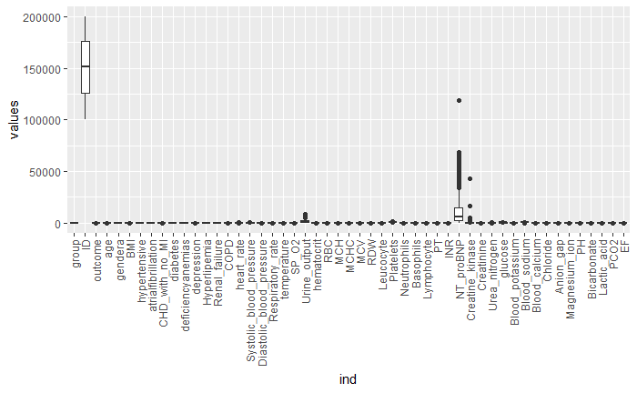

```r
          ggplot(stack(Data_Workable), aes(x = ind, y = values)) +
            geom_boxplot() +
            theme(axis.text.x = element_text(angle = 90, vjust = 0.5, hjust=1))

          par(mfrow=c(1,1))
```

## IV.- Manipulacion de Data

### Eliminacion de Atributos y Observaciones no relevantes para el estudio

Se procede a eliminar la observacion de ID 162338 por tener la variable de interes nula y los atributos “Group” e “ID” por no presentar relevancia para el estudio.

```r
      #1. Drop observation with outcome variable NA
          Data_Workable <- Data_Workable[!(Data_Workable$ID == "162338"),]

      #2. Drop Group and ID
          Data_Workable <- subset(Data_Workable, select = -c(group, ID))
          summary(Data_Workable)
```

```
    outcome            age           gendera           BMI          hypertensive    atrialfibrillation CHD_with_no_MI
 Min.   :0.0000   Min.   :19.00   Min.   :1.000   Min.   : 13.35   Min.   :0.0000   Min.   :0.0000     Min.   :0.00000
 1st Qu.:0.0000   1st Qu.:65.00   1st Qu.:1.000   1st Qu.: 24.33   1st Qu.:0.0000   1st Qu.:0.0000     1st Qu.:0.00000
 Median :0.0000   Median :77.00   Median :2.000   Median : 28.31   Median :1.0000   Median :0.0000     Median :0.00000
 Mean   :0.1352   Mean   :74.05   Mean   :1.526   Mean   : 30.19   Mean   :0.7177   Mean   :0.4515     Mean   :0.08588
 3rd Qu.:0.0000   3rd Qu.:85.00   3rd Qu.:2.000   3rd Qu.: 33.63   3rd Qu.:1.0000   3rd Qu.:1.0000     3rd Qu.:0.00000
 Max.   :1.0000   Max.   :99.00   Max.   :2.000   Max.   :104.97   Max.   :1.0000   Max.   :1.0000     Max.   :1.00000
                                                  NA's   :214
    diabetes      deficiencyanemias   depression     Hyperlipemia    Renal_failure         COPD           heart_rate
 Min.   :0.0000   Min.   :0.0000    Min.   :0.000   Min.   :0.0000   Min.   :0.0000   Min.   :0.00000   Min.   : 36.00
 1st Qu.:0.0000   1st Qu.:0.0000    1st Qu.:0.000   1st Qu.:0.0000   1st Qu.:0.0000   1st Qu.:0.00000   1st Qu.: 72.37
 Median :0.0000   Median :0.0000    Median :0.000   Median :0.0000   Median :0.0000   Median :0.00000   Median : 83.61
 Mean   :0.4209   Mean   :0.3393    Mean   :0.119   Mean   :0.3801   Mean   :0.3648   Mean   :0.07568   Mean   : 84.58
 3rd Qu.:1.0000   3rd Qu.:1.0000    3rd Qu.:0.000   3rd Qu.:1.0000   3rd Qu.:1.0000   3rd Qu.:0.00000   3rd Qu.: 95.91
 Max.   :1.0000   Max.   :1.0000    Max.   :1.000   Max.   :1.0000   Max.   :1.0000   Max.   :1.00000   Max.   :135.71
                                                                                                        NA's   :12
 Systolic_blood_pressure Diastolic_blood_pressure Respiratory_rate  temperature        SP_O2         Urine_output
 Min.   : 75.0           Min.   : 24.74           Min.   :11.14    Min.   :33.25   Min.   : 75.92   Min.   :   0
 1st Qu.:105.4           1st Qu.: 52.17           1st Qu.:17.93    1st Qu.:36.29   1st Qu.: 95.00   1st Qu.: 980
 Median :116.1           Median : 58.46           Median :20.37    Median :36.65   Median : 96.45   Median :1675
 Mean   :118.0           Mean   : 59.53           Mean   :20.80    Mean   :36.68   Mean   : 96.27   Mean   :1899
 3rd Qu.:128.6           3rd Qu.: 65.46           3rd Qu.:23.39    3rd Qu.:37.02   3rd Qu.: 97.92   3rd Qu.:2500
 Max.   :203.0           Max.   :107.00           Max.   :40.90    Max.   :39.13   Max.   :100.00   Max.   :8820
 NA's   :15              NA's   :15               NA's   :12       NA's   :18      NA's   :12       NA's   :35
   hematocrit         RBC             MCH             MCHC            MCV              RDW          Leucocyte
 Min.   :20.31   Min.   :2.030   Min.   :18.12   Min.   :27.82   Min.   : 62.60   Min.   :12.09   Min.   : 0.100
 1st Qu.:28.15   1st Qu.:3.120   1st Qu.:28.25   1st Qu.:32.01   1st Qu.: 86.25   1st Qu.:14.46   1st Qu.: 7.436
 Median :30.80   Median :3.489   Median :29.75   Median :32.99   Median : 90.00   Median :15.51   Median : 9.684
 Mean   :31.91   Mean   :3.575   Mean   :29.54   Mean   :32.86   Mean   : 89.90   Mean   :15.95   Mean   :10.715
 3rd Qu.:35.00   3rd Qu.:3.900   3rd Qu.:31.24   3rd Qu.:33.83   3rd Qu.: 93.86   3rd Qu.:16.94   3rd Qu.:12.744
 Max.   :55.42   Max.   :6.575   Max.   :40.31   Max.   :37.01   Max.   :116.71   Max.   :29.05   Max.   :64.750

   Platelets         Neutrophils      Basophils        Lymphocyte            PT             INR           NT_proBNP
 Min.   :   9.571   Min.   : 5.00   Min.   :0.1000   Min.   : 0.9667   Min.   :10.10   Min.   :0.8714   Min.   :    50
 1st Qu.: 168.904   1st Qu.:74.77   1st Qu.:0.2000   1st Qu.: 6.6333   1st Qu.:13.16   1st Qu.:1.1400   1st Qu.:  2250
 Median : 222.667   Median :82.47   Median :0.3000   Median :10.4667   Median :14.64   Median :1.3000   Median :  5838
 Mean   : 241.518   Mean   :80.12   Mean   :0.4057   Mean   :12.2327   Mean   :17.49   Mean   :1.6261   Mean   : 11011
 3rd Qu.: 304.278   3rd Qu.:87.46   3rd Qu.:0.5000   3rd Qu.:15.4750   3rd Qu.:18.80   3rd Qu.:1.7364   3rd Qu.: 14981
 Max.   :1028.200   Max.   :98.00   Max.   :8.8000   Max.   :83.5000   Max.   :71.27   Max.   :8.3429   Max.   :118928
                    NA's   :144     NA's   :259      NA's   :145       NA's   :20      NA's   :20
```

[output cut: 8 more lines]

```
    Chloride        Anion_gap      Magnesium_ion         PH         Bicarbonate     Lactic_acid         PCO2
 Min.   : 80.27   Min.   : 6.636   Min.   :1.400   Min.   :7.090   Min.   :12.86   Min.   :0.500   Min.   :18.75
 1st Qu.: 99.00   1st Qu.:12.250   1st Qu.:1.956   1st Qu.:7.335   1st Qu.:23.45   1st Qu.:1.200   1st Qu.:37.04
 Median :102.52   Median :13.667   Median :2.093   Median :7.380   Median :26.50   Median :1.600   Median :43.00
 Mean   :102.29   Mean   :13.924   Mean   :2.120   Mean   :7.379   Mean   :26.91   Mean   :1.853   Mean   :45.54
 3rd Qu.:105.57   3rd Qu.:15.404   3rd Qu.:2.242   3rd Qu.:7.430   3rd Qu.:29.88   3rd Qu.:2.200   3rd Qu.:50.59
 Max.   :122.53   Max.   :25.500   Max.   :4.073   Max.   :7.580   Max.   :47.67   Max.   :8.333   Max.   :98.60
                                                   NA's   :291                     NA's   :228     NA's   :293
       EF
 Min.   :15.00
 1st Qu.:40.00
 Median :55.00
 Mean   :48.71
 3rd Qu.:55.00
 Max.   :75.00
```

### Imputacion de datos faltantes

Se analiza para cada atributo que posea observaciones faltantes su correlacion con el resto de las variables y su comportamiento estadistico para determinar si realizar una imputacion con un modelo de regresion, o imputar con la media o la mediana de este.

```r
#----Data Manipulation: Imputation for Missing Values----

      #Data Backup
          Data_Imputed <- Data_Workable
          attach(Data_Workable)
      #1. BMI----

          # 214/1176
          # 18.19%

          #Cor
              options(scipen=999)
              data_cor <- cor(Data_Workable[ , colnames(Data_Workable) != "BMI"],Data_Workable$BMI, use='complete.obs');data_cor
```

```
                                   [,1]
outcome                  -0.10330028289
age                      -0.37503606470
gendera                  -0.01589529551
hypertensive             -0.02836551993
atrialfibrillation       -0.11504122064
CHD_with_no_MI           -0.03954454661
diabetes                  0.14145639230
deficiencyanemias        -0.04933965934
depression                0.03583393733
Hyperlipemia             -0.00974975324
Renal_failure            -0.02235161574
COPD                      0.00928535611
heart_rate               -0.00008124379
Systolic_blood_pressure   0.05344846240
Diastolic_blood_pressure  0.11390413664
Respiratory_rate         -0.09221666833
temperature               0.04967761464
SP_O2                    -0.13577407052
Urine_output              0.26706876248
hematocrit                0.16222076330
RBC                       0.20071909869
MCH                      -0.15044319235
MCHC                     -0.12732331518
MCV                      -0.10893590408
RDW                       0.08741073211
Leucocyte                -0.09331805202
Platelets                -0.11441852703
Neutrophils              -0.13075182185
Basophils                 0.07583358190
Lymphocyte                0.11438766412
PT                        0.01000158343
INR                       0.00685695440
NT_proBNP                -0.17115162455
Creatine_kinase           0.03935299040
Creatinine                0.00842072898
Urea_nitrogen            -0.04515249584
glucose                   0.08758654573
Blood_potassium          -0.00035032041
Blood_sodium              0.02988744965
Blood_calcium             0.11907575310
Chloride                 -0.22360471800
Anion_gap                -0.14107170582
Magnesium_ion             0.01028549159
PH                       -0.10325008480
Bicarbonate               0.28488709501
Lactic_acid              -0.11555437068
PCO2                      0.31521527334
EF                        0.08624204406
```

```r
              #Resp: Low to All

          par(mfrow=c(1,3))
          #Behavior
              hist(Data_Workable$BMI, main = "Histograma de BMI", xlab = col)
              qqnorm(Data_Workable$BMI)
```

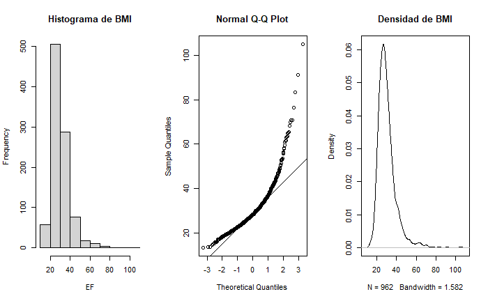

```r
              qqline(Data_Workable$BMI)
              dens = density(Data_Workable$BMI, na.rm = TRUE)
              plot(dens, main ="Densidad de BMI")
```

```r
              #Resp: Not Normal

          #Simple imputation: Median
              Data_Imputed$BMI[is.na(Data_Imputed$BMI)] <- median(Data_Imputed$BMI, na.rm = TRUE)
              summary(Data_Imputed$BMI)
```

```
   Min. 1st Qu.  Median    Mean 3rd Qu.    Max.
  13.35   25.27   28.31   29.85   32.10  104.97
```

```r
              summary(Data_Workable$BMI)
```

```
   Min. 1st Qu.  Median    Mean 3rd Qu.    Max.    NA's
  13.35   24.33   28.31   30.19   33.63  104.97     214
```

```r
      #2. Heart rate----

          #12/1176
          #1.02%

          #Cor
              data_cor <- cor(Data_Workable[ , colnames(Data_Workable) != "heart_rate"],Data_Workable$heart_rate, use='complete.obs');data_cor
```

```
                                   [,1]
outcome                   0.15425231822
age                      -0.21488964313
gendera                  -0.05870706514
BMI                      -0.00008124379
hypertensive             -0.11264666390
atrialfibrillation        0.01294007035
CHD_with_no_MI           -0.02070792948
diabetes                 -0.11522271068
deficiencyanemias        -0.11007578761
depression               -0.02166374403
Hyperlipemia             -0.08027018128
Renal_failure            -0.21379875630
COPD                      0.00739140769
Systolic_blood_pressure  -0.13650901938
Diastolic_blood_pressure  0.30095759273
Respiratory_rate          0.39509625999
temperature               0.23581968419
SP_O2                    -0.06258148603
Urine_output              0.04189864115
hematocrit                0.00818347624
RBC                       0.02231314996
MCH                      -0.02531496326
MCHC                     -0.01057170150
MCV                      -0.02869755555
RDW                      -0.01820069745
Leucocyte                 0.16327821202
Platelets                 0.06131383802
Neutrophils               0.05046589195
Basophils                -0.01445963622
Lymphocyte               -0.08637273402
PT                        0.02279570919
INR                       0.01613890104
NT_proBNP                -0.02508285835
Creatine_kinase           0.11529081631
Creatinine               -0.08886169072
Urea_nitrogen            -0.11085441224
glucose                   0.10452684561
Blood_potassium           0.01410842788
Blood_sodium             -0.07067430865
Blood_calcium            -0.12380309637
Chloride                  0.01794958934
Anion_gap                 0.08909324017
Magnesium_ion            -0.09862104040
PH                        0.04784199001
Bicarbonate              -0.11095488874
Lactic_acid               0.25340457092
PCO2                     -0.09047085116
EF                       -0.11307414482
```

```r
              #Resp: Low to All

          #Behavior
              hist(Data_Workable$heart_rate, xlab = col)
              qqnorm(Data_Workable$heart_rate)
```

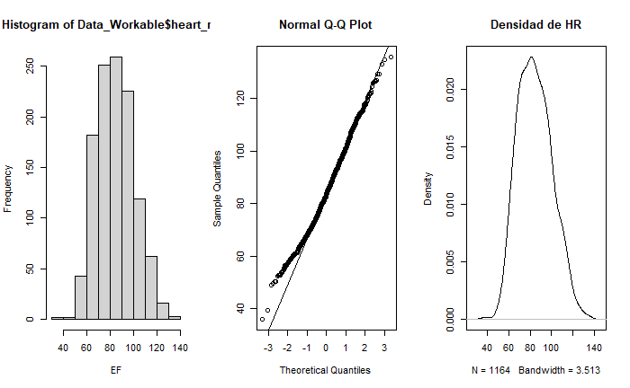

```r
              qqline(Data_Workable$heart_rate)
              dens = density(Data_Workable$heart_rate, na.rm = TRUE)
              plot(dens, main ="Densidad de HR")
```

```r
              #Resp: Maybe Normal

          #Hyp. test
              resultsSW <- shapiro.test(Data_Workable$heart_rate);resultsSW
```

```
    Shapiro-Wilk normality test

data:  Data_Workable$heart_rate
W = 0.99009, p-value = 0.0000004535
```

```r
              resultsAD <- ad.test(Data_Workable$heart_rate);resultsAD
```

```
    Anderson-Darling normality test

data:  Data_Workable$heart_rate
A = 3.138, p-value = 0.00000007182
```

```r
              resultsKS <- ks.test(Data_Workable$heart_rate, "pnorm", mean(Data_Workable$heart_rate), sd(Data_Workable$heart_rate));resultsKS
```

```
    Asymptotic one-sample Kolmogorov-Smirnov test

data:  Data_Workable$heart_rate
D = NA, p-value = NA
alternative hypothesis: two-sided
```

```r
              #Non conclusive, not normal

          #Simple imputation: Median
              Data_Imputed$heart_rate[is.na(Data_Imputed$heart_rate)] <- median(Data_Imputed$heart_rate, na.rm = TRUE)
              summary(Data_Imputed$heart_rate)
```

```
   Min. 1st Qu.  Median    Mean 3rd Qu.    Max.
  36.00   72.54   83.61   84.57   95.61  135.71
```

```r
              summary(Data_Workable$heart_rate)
```

```
   Min. 1st Qu.  Median    Mean 3rd Qu.    Max.    NA's
  36.00   72.37   83.61   84.58   95.91  135.71      12
```

```r
      #3. Systolic----

          #15/1176
          #1.27%

          #Cor
              data_cor <- cor(Data_Workable[ , colnames(Data_Workable) != "Systolic_blood_pressure"],Data_Workable$Systolic_blood_pressure, use='complete.obs');data_cor
```

```
                                  [,1]
outcome                  -0.1293903781
age                      -0.0157942973
gendera                   0.0795940231
BMI                       0.0534484624
hypertensive              0.1605944935
atrialfibrillation       -0.1340243552
CHD_with_no_MI           -0.0949360088
diabetes                  0.1111160548
deficiencyanemias         0.0849306674
depression                0.0420147758
Hyperlipemia             -0.0841114506
Renal_failure             0.1232005380
COPD                     -0.0553045683
heart_rate               -0.1365090194
Diastolic_blood_pressure  0.4108355992
Respiratory_rate         -0.1108542886
temperature               0.0668086815
SP_O2                     0.0320453605
Urine_output              0.1888073053
hematocrit               -0.0469814735
RBC                      -0.0403091955
MCH                       0.0084228501
MCHC                      0.0635881931
MCV                      -0.0239790827
RDW                      -0.0590314799
Leucocyte                -0.0907944359
Platelets                 0.1047720317
Neutrophils              -0.0518331963
Basophils                 0.0513698726
Lymphocyte                0.0628186053
PT                       -0.1285528164
INR                      -0.1245433210
NT_proBNP                -0.0766948384
Creatine_kinase          -0.0245235349
Creatinine                0.1065374923
Urea_nitrogen             0.0002288257
glucose                   0.0087509405
Blood_potassium          -0.0669798908
Blood_sodium              0.0688581127
Blood_calcium             0.1328451137
Chloride                 -0.0514766662
Anion_gap                -0.0047397342
Magnesium_ion             0.0714829313
PH                        0.1543480625
Bicarbonate               0.0968655633
Lactic_acid              -0.1452348982
PCO2                      0.0308401514
EF                        0.2304950366
```

```r
              #Resp: Low for all

          #Behavior
              hist(Data_Workable$Systolic_blood_pressure, xlab = col)
              qqnorm(Data_Workable$Systolic_blood_pressure)
```

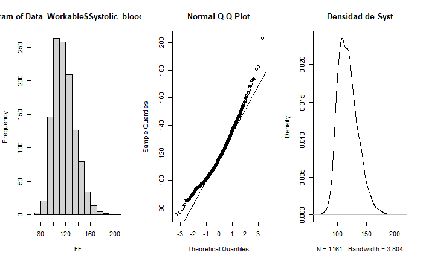

```r
              qqline(Data_Workable$Systolic_blood_pressure)
              dens = density(Data_Workable$Systolic_blood_pressure, na.rm = TRUE)
              plot(dens, main ="Densidad de Syst")
```

```r
              #Resp: Maybe Normal

          #Hyp. test
              resultsSW <- shapiro.test(Data_Workable$Systolic_blood_pressure);resultsSW
```

```
    Shapiro-Wilk normality test

data:  Data_Workable$Systolic_blood_pressure
W = 0.97087, p-value = 0.00000000000001591
```

```r
              resultsAD <- ad.test(Data_Workable$Systolic_blood_pressure);resultsAD
```

```
    Anderson-Darling normality test

data:  Data_Workable$Systolic_blood_pressure
A = 8.2394, p-value < 0.00000000000000022
```

```r
              resultsKS <- ks.test(Data_Workable$Systolic_blood_pressure, "pnorm", mean(Data_Workable$Systolic_blood_pressure), sd(Data_Workable$Systolic_blood_pressure))
              #Non conclusive, not normal

          #Simple imputation: Median
              Data_Imputed$Systolic_blood_pressure[is.na(Data_Imputed$Systolic_blood_pressure)] <- median(Data_Imputed$Systolic_blood_pressure, na.rm = TRUE)
              summary(Data_Imputed$Systolic_blood_pressure)
```

```
   Min. 1st Qu.  Median    Mean 3rd Qu.    Max.
   75.0   105.5   116.1   118.0   128.5   203.0
```

```r
              summary(Data_Workable$Systolic_blood_pressure)
```

```
   Min. 1st Qu.  Median    Mean 3rd Qu.    Max.    NA's
   75.0   105.4   116.1   118.0   128.6   203.0      15
```

```r
      #4. Diastolic----

          #15/1176
          #1.27%

          #Cor
              data_cor <- cor(Data_Workable[ , colnames(Data_Workable) != "Diastolic_blood_pressure"],Data_Workable$Diastolic_blood_pressure,use='complete.obs');data_cor
```

```
                                  [,1]
outcome                 -0.10839119429
age                     -0.28083130303
gendera                 -0.16048590896
BMI                      0.11390413664
hypertensive            -0.03037978774
atrialfibrillation      -0.05447687098
CHD_with_no_MI          -0.08369861213
diabetes                -0.00006653227
deficiencyanemias       -0.16282108873
depression               0.11021494992
Hyperlipemia            -0.03702123341
Renal_failure           -0.08057110672
COPD                     0.02181071494
heart_rate               0.30095759273
Systolic_blood_pressure  0.41083559918
Respiratory_rate         0.10479609557
temperature              0.02481998154
SP_O2                   -0.12627457252
Urine_output             0.17729131012
hematocrit               0.31293060168
RBC                      0.29218075272
MCH                      0.01963011224
MCHC                     0.04378801365
MCV                     -0.00643754273
RDW                     -0.05490566856
Leucocyte               -0.04780367108
Platelets                0.09793436635
Neutrophils             -0.08132312634
Basophils                0.14432679305
Lymphocyte               0.11683672423
PT                      -0.02665538633
INR                     -0.02729704311
NT_proBNP               -0.03392641659
Creatine_kinase         -0.04583004142
Creatinine              -0.02497952276
Urea_nitrogen           -0.15629187797
glucose                  0.02652269109
Blood_potassium         -0.00566621959
Blood_sodium            -0.04036588891
Blood_calcium            0.16929221894
Chloride                -0.14192567763
Anion_gap                0.06639643069
Magnesium_ion           -0.08244430596
PH                       0.15614306997
Bicarbonate              0.06976756789
Lactic_acid              0.07133973989
PCO2                    -0.02517028271
EF                      -0.13003611661
```

```r
              #Resp: Low for all, 0.4 Systolic

          #Behavior
              hist(Data_Workable$Diastolic_blood_pressure)
              qqnorm(Data_Workable$Diastolic_blood_pressure)
```

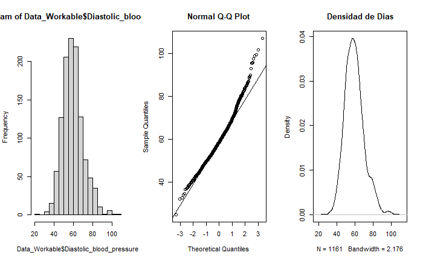

```r
              qqline(Data_Workable$Diastolic_blood_pressure)
              dens = density(Data_Workable$Diastolic_blood_pressure, na.rm = TRUE)
              plot(dens, main ="Densidad de Dias")
```

```r
              #Resp: Maybe Normal

          #Hyp. test
              resultsSW <- shapiro.test(Data_Workable$Diastolic_blood_pressure);resultsSW
```

```
    Shapiro-Wilk normality test

data:  Data_Workable$Diastolic_blood_pressure
W = 0.97954, p-value = 0.000000000009681
```

```r
              resultsAD <- ad.test(Data_Workable$Diastolic_blood_pressure);resultsAD
```

```
    Anderson-Darling normality test

data:  Data_Workable$Diastolic_blood_pressure
A = 5.3499, p-value = 0.0000000000003313
```